# Autokorelačná funkcia, Ljung-Boxov test

Časové rady, Beáta Stehlíková, FMFI UK Bratislava

# 1 Výstup z funkcie Box.test

Pre určité dáta bol Ljung-Boxovým testom získaný nasledovný výstup:

```
##
##  Box-Ljung test
##
## data:  x
## X-squared = 4.638, df = 5, p-value = 0.4616
```

- Aká hypotéza sa testovala?
- Aký je záver - zamietame túto hypotézu alebo nie?
- Čo z toho vyplýva pre dáta? Zamietneme už na základe tohto testu hypotézu, že ide o biely šum? Ak nie, aké ďalšie testy by sme mali spraviť, aby sme sa k tejto otázke mohli lepšie vyjadriť?

# 2 Ljung-Boxova štatistika a p-hodnota

- Z hodnoty testovacej štatistiky v predchádzajúcom výstupe vypočítajte p-hodnotu.
- Dáta, ktoré boli použité v predchádzajúcom výstupe majú nasledovné hodnoty odhadnutej autokorelačnej funkcie. Vypočítajte pomocou nich hodnotu testovacej štatistiky, ak navyše vieme, že počet pozorovaní bol 100.

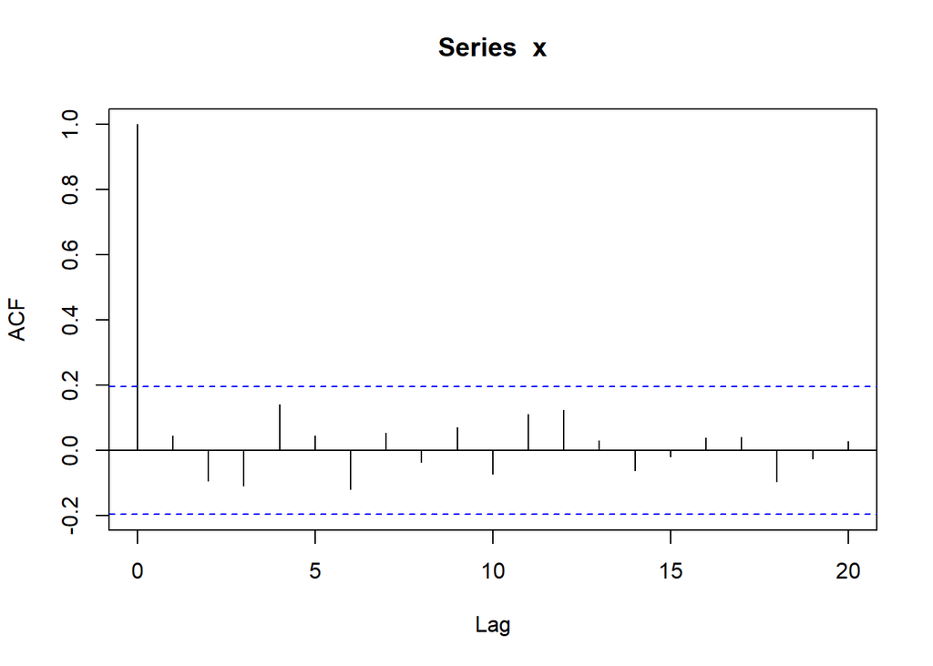

```
## [1]  1.0000  0.0442 -0.0935 -0.1079  0.1401  0.0450 -0.1186  0.0539 -0.0361
```

Malý rozdiel vo výsledku môže vzniknúť kvôli tomu, že výpočty robíme so zaokrúhlenými hodnotami.

# 3 Ljung-Boxov test pre viac lagov a grafické znázornenie I. (simulované dáta)

Cieľom je zrekonštruovať grafický výstup na strane 44 (dáta sú generované na strane 43) slajdov z prednášky: (http://www.iam.fmph.uniba.sk/institute/stehlikova/cr23/prednasky/cr01_uvod.pdf)

Použijeme pritom dva postupy:

- Pomocou *for* cyklu
- funkciu *sapply* z triedy funkcií *apply*, keďže cykly sú vo všeobecnosti v R pomalé a odporúča sa používať namiesto nich tento prístup (*s* v názve označuje zjednodušenie výstupu, v našom prípade na vektor)

**Príklad použitia funkcie *sapply*:**

```r
# sucet 1^2 + 2^2 + ... + k^2
k <- 1:10
sapply(k, FUN = function(n) sum((1:n)^2))
```

```
##  [1]   1   5  14  30  55  91 140 204 285 385
```

```r
# sucet 1^p + 2^p + ... + k^p
k <- 1:10
sapply(k, FUN = function(n, p) sum((1:n)^p), p = 2)
```

```
##  [1]   1   5  14  30  55  91 140 204 285 385
```

**V našom prípade:**

Použité dáta môžu byť:

- pevne zvolené (analógia prvého vzorového príkladu z predchádzajúceho slajdu)
- alebo môžu byť parametrom funkcie `FUN` (analógia druhého vzorového príkladu)

Oplatí sa nastaviť y-ovú os na interval $(0, 1)$, aby bol skript univerzálny pre všetky dáta, aby sa vždy (aj pri vysokých p hodnotách) dala vidieť vyznačená hodnota 0.05, s ktorou p hodnoty porovnávame.

# 4 Ljung-Boxov test pre viac lagov a grafické znázornenie II. (reálne dáta)

Zopakujte predchádzajúci výpočet pre dáta o prietokoch Nílu z prednášky (str. 46) a interpretujte výsledky.

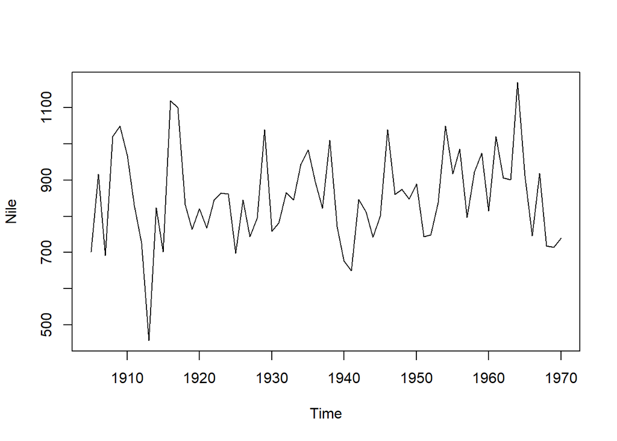

```r
x <- window(Nile, start = 1905)
plot(x, ylab = "Nile")
```

# 5 Analýza výnosov akcií pomocou balíka `quantmod`

Načítajte (ak treba, aj nainštalujte) balík `quantmod`.

```r
library(quantmod)
```

## 5.1 Získanie cien akcií

Na získanie cien akcií sa použije funkcia `getSymbols`, napríklad:

```r
getSymbols("EBAY", from = "2022-01-01", to = "2022-12-31")
```

```
## [1] "EBAY"
```

Pozrime sa, ako vyzerajú naše dáta, ktoré sú uložené v premennej `EBAY`, zobrazíme ich začiatok:

```r
head(EBAY)
```

```
##            EBAY.Open EBAY.High EBAY.Low EBAY.Close EBAY.Volume EBAY.Adjusted
## 2022-01-03     66.45     67.12    65.66      66.80     6685500      64.45943
## 2022-01-04     67.17     67.42    64.44      65.14     7527300      62.85760
## 2022-01-05     64.87     66.27    64.46      64.49     7440700      62.23037
## 2022-01-06     64.14     67.49    64.08      66.81     8218400      64.46908
## 2022-01-07     66.73     67.33    66.28      66.32     5000900      63.99626
## 2022-01-10     65.72     66.33    63.72      64.57     6684000      62.30756
```

## 5.2 Jednoduché ukážky funkcií z balíka:

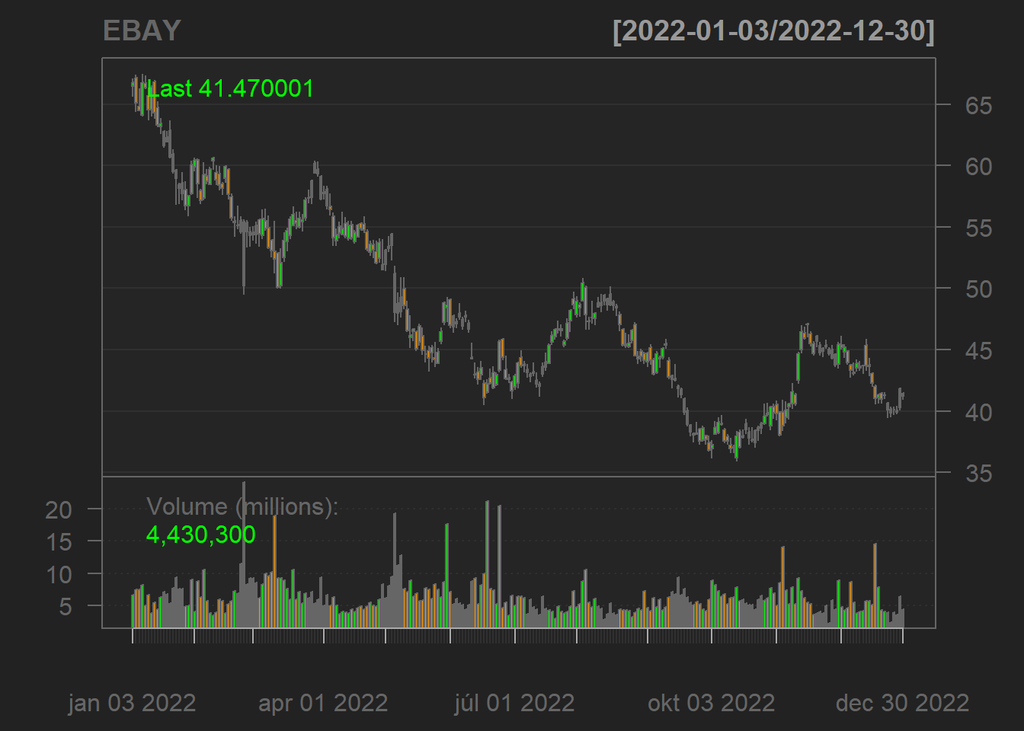

```r
chartSeries(EBAY)
```

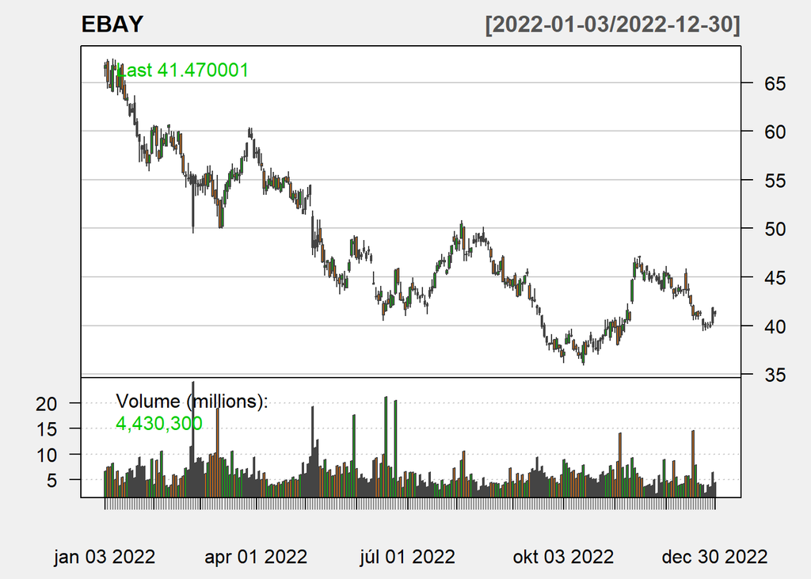

```r
chartSeries(EBAY, theme="white")
```

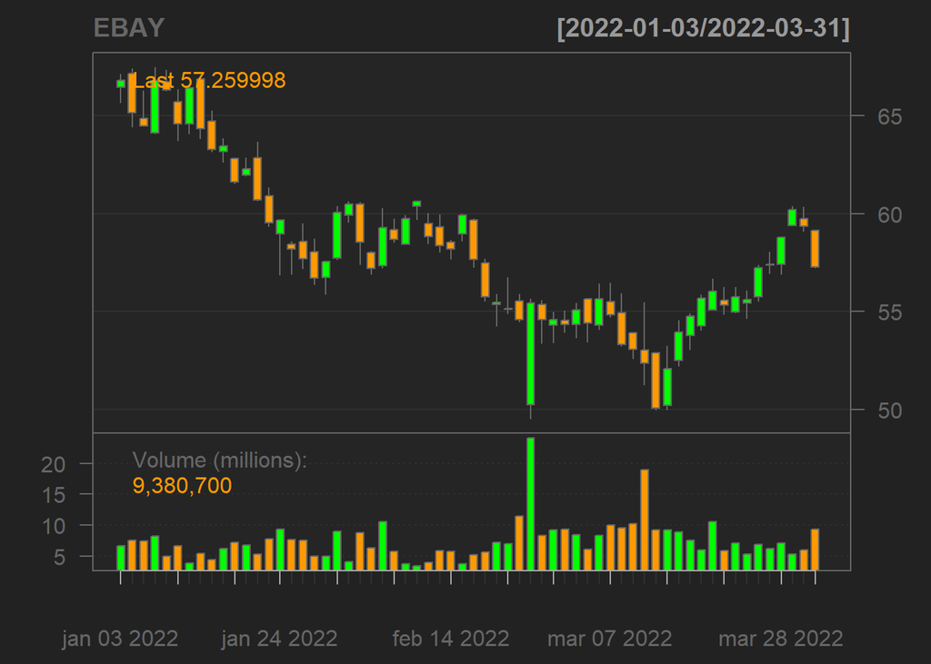

```r
chartSeries(EBAY, subset="2022-01::2022-03") # od januara do marca
```

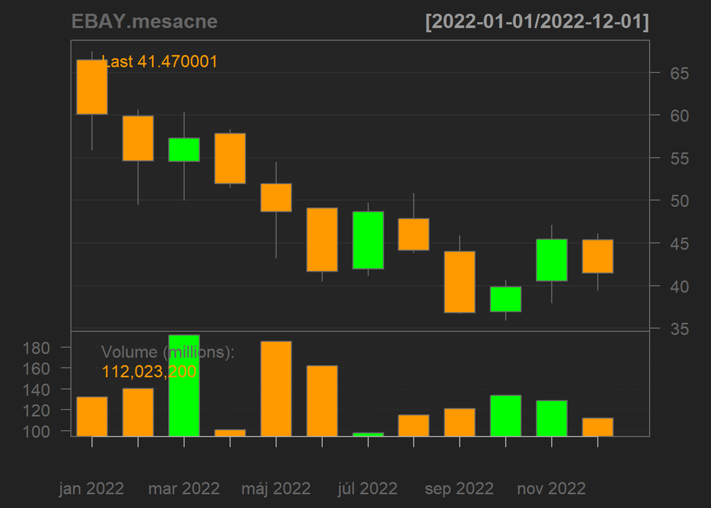

```r
EBAY.mesacne <- to.monthly(EBAY)  # mesacne data
chartSeries(EBAY.mesacne)         # graf
```

## 5.3 Práca s výnosmi

Budeme pracovať s výnosmi akcií. Z našich dát `EBAY` budeme potrebovať posledný stĺpec (`EBAY.Adjusted`), z ktorého vypočítame výnosy. Budeme pracovať zo spojitými výnosmi, teda denné výnosy sa budú počítať ako logaritmus podielu cien v dvoch po sebe idúcich dňoch. Ekvivalentne - ako rozdiel logaritmov (takto sa dá použiť funkcia `diff` na výpočet diferencií).

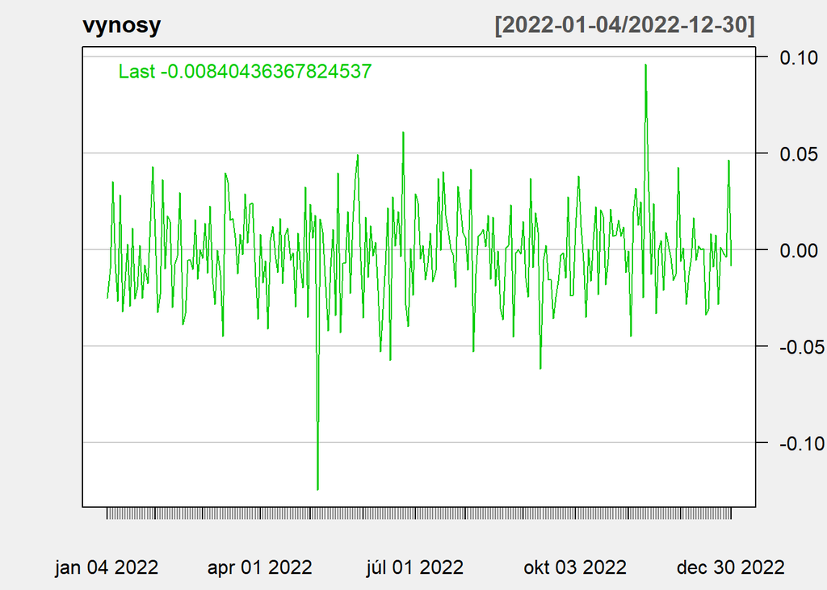

```r
ceny <- EBAY$EBAY.Adjusted
vynosy <- diff(log(ceny))
chartSeries(vynosy, theme="white")
```

**Zadanie:** Zobrazte odhad ACF. Sú autokorelácie signifikantné? Pomocou Ljung-Boxovho testu testujte hypotézu, že výnosy sú nekorelované (teda že sú súčtom konštanty - priemerný výnos - a bieleho šumu).

# 6 Ďalšie príklady na precvičenie

## 6.1 Testovacia štatistika Ljung-Boxovho testu

Vygenerujme dáta, ktoré **sú** nekorelované. Napríklad:

```r
x <- rnorm(100, mean = 10, sd = 3)  # iid N(10, 3^2)
```

Budeme testovať hypotézu, že prvých 5 autokorelácií je nulových a zaznamenáme hodnotu testovacej štatistiky:

```r
# DOPLNTE
simulacia <- function(){
  x <- rnorm(100, mean = 10, sd = 3)
  LB <- Box.test(x, ...)
  return(...)
}
```

Zopakujeme 1000 krát - pri opakovaní simulácií je užitočná funkcia `replicate` - a zobrazíme histogram:

```r
statistiky <- replicate(1000, simulacia())
hist(statistiky)
```

Aká je teoretická hustota rozdelenia štatistiky v Ljung-Boxovom teste? Porovnajte so získaným histogramom.

Ukážka výstupu (kvôli náhodnosti môžete dostať iný):

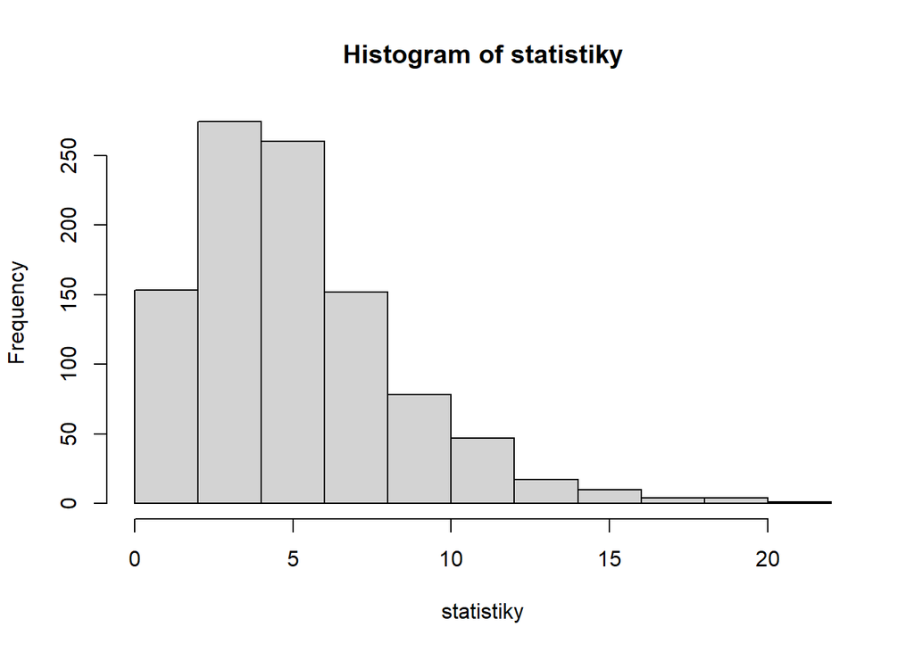

**Zadanie:**

- Zopakujte simulácie:
  - pre iný počet dát,
  - pre iné rozdelenie generovaných náhodných veličín, ktoré sú bielym šumom,
  - pre iný počet lagov.
- Zobrazte:
  - histogram a jeho porovnanie s hustotou,
  - kvantil a jeho porovnanie s kritickou hodnotou LB testu.

## 6.2 Teoretický príklad

*Jeden teoretický príklad tohto typu je v hodnote 10 bodov súčasťou skúšky.*

Nech $u$ je biely šum, ktorého hodnoty sú nezávislé náhodné premenné s normálnym rozdelením. Definujme proces $x_t = u_t u_{t-1}$. Vypočítajte jeho strednú hodnotu, disperziu a autokovariancie. Rozhodnite, či je tento proces stacionárny.

Vygenerujte realizáciu tohto procesu a zobrazte odhadnutú autokorelačnú funkciu.

# 7 Poznámka: R markdown

R markdown bol použitý aj na vytvorenie tejto stránky priamo v R-ku, takisto na vytvorenie slajdov k prednáške.

- R markdown: http://rmarkdown.rstudio.com/
- Konkrétne HTML dokumenty: https://bookdown.org/yihui/rmarkdown/html-document.html
- Užitočný môže byť aj interaktívny notebook: https://bookdown.org/yihui/rmarkdown/notebook.htm